# Work on large numeric tables with R

# Introduction

## Purpose

Loading and filtering large tables is a common task in the fields of Biology and Bioinformatics. Being able to process all floating point, commas and power of 10 as numbers is a very simple thing with `R`, and other programming languages.

## Expectations

At the end of this session, you will be able to:

# Load count table in memory

Loading a table in R is being done with the function [`read.table`](https://www.rdocumentation.org/packages/utils/versions/3.6.2/topics/read.table) form the package [`utils`](https://www.rdocumentation.org/packages/utils/versions/3.6.2). Remember, specifying the package name is facultative, but very important when you want to share, reproduce, and make your work accessible. These are the keys of the [FAIR principles](https://fr.wikipedia.org/wiki/Fair_data).

```r
counts <- utils::read.table(
    file="EMT_count_data.txt",   # Path to the table
)
```

Let’s see the content of the table, using the function [`head`](https://www.rdocumentation.org/packages/utils/versions/3.6.2/topics/head) from package [`utils`](https://www.rdocumentation.org/packages/utils/versions/3.6.2).

```r
utils::head(x = counts)
```

First five lines of the wrongly parsed table

| V1 |
| --- |
| Gene_Symbol,Day_0_R1,Day_0_R2,Day_0_R3,Day_7_R1,Day_7_R2,Day_7_R3 |
| A1BG,4,6,2,7,6,7 |
| A1CF,41,33,42,32,42,32 |
| A2M,1,3,1,4,3,7 |
| A2ML1,3,2,2,6,7,3 |
| A2MP1,3,2,2,1,1,0 |

Oh, there is a problem here… Help me identify all our issues here.

**List of issues**

1. Columns are not separated correctly
2. Header is not recognized
3. Row names are considered as a column

**Solution**

```r
counts <- utils::read.table(
    file="EMT_count_data.txt",
    header=TRUE,
    sep=",",
    row.names=1
)
```

We use the [`head`](https://www.rdocumentation.org/packages/utils/versions/3.6.2/topics/head) function again…

```r
utils::head(x = counts)
```

First five lines of the correctly parsed table

|  | Day_0_R1 | Day_0_R2 | Day_0_R3 | Day_7_R1 | Day_7_R2 | Day_7_R3 |
| --- | --- | --- | --- | --- | --- | --- |
| A1BG | 4 | 6 | 2 | 7 | 6 | 7 |
| A1CF | 41 | 33 | 42 | 32 | 42 | 32 |
| A2M | 1 | 3 | 1 | 4 | 3 | 7 |
| A2ML1 | 3 | 2 | 2 | 6 | 7 | 3 |
| A2MP1 | 3 | 2 | 2 | 1 | 1 | 0 |
| A3GALT2 | 1 | 4 | 4 | 3 | 2 | 1 |

It looks just as it shoud!

## Conclusion

Always look at your data. Always print the first rows as a quality control. No exceptions.

# Search gene(s) of interest

## Search gene names in the table

On can access any sample of gene using their name.

Let’s search for the gene [`ENO1`](https://www.genecards.org/cgi-bin/carddisp.pl?gene=ENO1):

```r
counts["ENO1", ]
```

```
     Day_0_R1 Day_0_R2 Day_0_R3 Day_7_R1 Day_7_R2 Day_7_R3
ENO1   209313   186201   176277    98411   100989   106017
```

Let’s focus on the sample `Day_0_R1`:

```r
counts["ENO1", "Day_0_R1"]
```

```
[1] 209313
```

We can also search for a list of genes:

```r
counts[c("ENO1", "KRT8"), ]
```

```
     Day_0_R1 Day_0_R2 Day_0_R3 Day_7_R1 Day_7_R2 Day_7_R3
ENO1   209313   186201   176277    98411   100989   106017
KRT8   114696   103002    93520    31338    32099    33457
```

Or within a range of samples:

```r
counts[
    c("ENO1", "KRT8"),
    c("Day_0_R1", "Day_0_R2", "Day_0_R3")
]
```

```
     Day_0_R1 Day_0_R2 Day_0_R3
ENO1   209313   186201   176277
KRT8   114696   103002    93520
```

## Search with substrings

We can also use the function [`grep`](https://www.rdocumentation.org/packages/base/versions/3.6.2/topics/grep) from package [`base`](https://www.rdocumentation.org/packages/base/versions/3.6.2) to access to all *“Day_1”* samples, with:

```r
counts[, base::grepl(pattern="Day_1.*", x=base::colnames(counts))]
```

| A1BG |
| --- |
| A1CF |
| A2M |
| A2ML1 |
| A2MP1 |
| A3GALT2 |

Or *rRNA* related gene symbols:

```r
counts[base::grepl(pattern=".*RRNA.*", x=base::rownames(counts), ignore.case=TRUE), ]
```

|  | Day_0_R1 | Day_0_R2 | Day_0_R3 | Day_7_R1 | Day_7_R2 | Day_7_R3 |
| --- | --- | --- | --- | --- | --- | --- |
| RRNAD1 | 2003 | 1776 | 1725 | 1113 | 1235 | 1227 |

[Regular expressions](https://en.wikipedia.org/wiki/Regular_expression) is a very, **very** powerful tool. We won’t cover it here. I warmly invite you to explore further with Regular expressions.

## Conclusion

One can access any range of values within a data frame with: `data_frame_name[rows, columns]`.

# Transpose, melt, explode, and sort data

Most of the time, you will need to reshape your data.

## Transpose

You may want to invert the row/columns, this is done with the function [`t`](https://www.rdocumentation.org/packages/base/versions/3.6.2/topics/t) from [`base`](https://www.rdocumentation.org/packages/base/versions/3.6.2/) package.

```r
transposed <- base::t(counts)
```

Then we check the results with the function [`head`](https://www.rdocumentation.org/packages/utils/versions/3.6.2/topics/head) from the [`utils`](https://www.rdocumentation.org/packages/utils/versions/3.6.2/) package.

```r
utils::head(x=transposed)
```

Sample identifiers in row, gene names in columns

|  | A1BG | A1CF | A2M | A2ML1 | A2MP1 |
| --- | --- | --- | --- | --- | --- |
| Day_0_R1 | 4 | 41 | 1 | 3 | 3 |
| Day_0_R2 | 6 | 33 | 3 | 2 | 2 |
| Day_0_R3 | 2 | 42 | 1 | 2 | 2 |
| Day_7_R1 | 7 | 32 | 4 | 6 | 1 |
| Day_7_R2 | 6 | 42 | 3 | 7 | 1 |
| Day_7_R3 | 7 | 32 | 7 | 3 | 0 |

## Melt

We can reduce the number of column while keeping the exact same amount of data. This reorganisation of the data is called `melting` data.

We can do it with the function [`melt`](https://www.rdocumentation.org/packages/reshape2/versions/1.4.4/topics/melt) from the package [`reshape2`](https://www.rdocumentation.org/packages/reshape2/versions/1.4.4).

This is usefull to plot counts according to sample identifiers, or counts according to experimental conditions, etc.

```r
base::library(package="reshape2", character.only=TRUE)

# Don't forget to include your row names into
# your data frame, or they will be lost.
named_counts <- counts
named_counts$Gene_Symbol <- row.names(counts)

molten_counts <- reshape2::melt(
    data=named_counts,
    variable.name="Sample_id",
    value.name="Gene_Expression"
)
```

Then we check the results with the function [`head`](https://www.rdocumentation.org/packages/utils/versions/3.6.2/topics/head) from the [`utils`](https://www.rdocumentation.org/packages/utils/versions/3.6.2/) package.

```r
utils::head(x=molten_counts)
```

First five lines of the molten table

| Gene_Symbol | Sample_id | Gene_Expression |
| --- | --- | --- |
| A1BG | Day_0_R1 | 4 |
| A1CF | Day_0_R1 | 41 |
| A2M | Day_0_R1 | 1 |
| A2ML1 | Day_0_R1 | 3 |
| A2MP1 | Day_0_R1 | 3 |
| A3GALT2 | Day_0_R1 | 1 |

## Explode (un-melt)

In the case you recieved molten data, and you’d like to recover the wide original table. This action is called `exploding` a table, or sometimes `un-melting` a table.

We can do it with the function [`cast`](https://www.rdocumentation.org/packages/reshape2/versions/1.4.4/topics/cast) from the package [`reshape2`](https://www.rdocumentation.org/packages/reshape2/versions/1.4.4/).

```r
exploded <- reshape2::dcast(
    data=molten_counts,
    formula=Gene_Symbol~Sample_id,
    value.var="Gene_Expression"
)
```

Then we check the results with the function [`head`](https://www.rdocumentation.org/packages/utils/versions/3.6.2/topics/head) from the [`utils`](https://www.rdocumentation.org/packages/utils/versions/3.6.2/) package.

```r
utils::head(x=exploded)
```

First five lines of the exploded table

| Gene_Symbol | Day_0_R1 | Day_0_R2 | Day_0_R3 | Day_7_R1 | Day_7_R2 | Day_7_R3 |
| --- | --- | --- | --- | --- | --- | --- |
| A1BG | 4 | 6 | 2 | 7 | 6 | 7 |
| A1CF | 41 | 33 | 42 | 32 | 42 | 32 |
| A2M | 1 | 3 | 1 | 4 | 3 | 7 |
| A2ML1 | 3 | 2 | 2 | 6 | 7 | 3 |
| A2MP1 | 3 | 2 | 2 | 1 | 1 | 0 |
| A3GALT2 | 1 | 4 | 4 | 3 | 2 | 1 |

## Sort

We often wand to sort data. Usually, sorting them from the highest variable genes to the lowest: this help us quickly see if our genes of interest are variable among our conditions. It is a quick quality check for any RNASeq experiment.

We are going to apply the function [`var`](https://www.rdocumentation.org/packages/stats/versions/3.6.2/topics/cor) from the package [`stats`](https://www.rdocumentation.org/packages/stats/versions/3.6.2), using the function [`apply`](https://www.rdocumentation.org/packages/base/versions/3.6.2/topics/apply) from the package [`base`](https://www.rdocumentation.org/packages/base/versions/3.6.2/).

```r
gene_var <- base::apply(X=counts, MARGIN=1, FUN=stats::var)
```

Then we check the results with the function [`head`](https://www.rdocumentation.org/packages/utils/versions/3.6.2/topics/head) from the [`utils`](https://www.rdocumentation.org/packages/utils/versions/3.6.2/) package.

```r
utils::head(x=gene_var)
```

First five lines of the variance table

|  | x |
| --- | --- |
| A1BG | 3.866667 |
| A1CF | 26.400000 |
| A2M | 4.966667 |
| A2ML1 | 4.566667 |
| A2MP1 | 1.100000 |
| A3GALT2 | 1.900000 |

We find the most variable genes with the function [`sort`](https://www.rdocumentation.org/packages/base/versions/3.6.2/topics/sort) from [`base`](https://www.rdocumentation.org/packages/base/versions/3.6.2/topics/sort) package, and get their names with the function [`names`](https://www.rdocumentation.org/packages/base/versions/3.6.2/topics/names) from the same package.

```r
var_gene_names <- base::names(
    base::sort(
        x=gene_var,
        decreasing=TRUE
    )
)
utils::head(var_gene_names)
```

```
[1] "FASN"   "SCD"    "ENO1"   "KRT8"   "FN1"    "S100A6"
```

And now, we apply the sort on our original table:

```r
sorted_counts <- counts[var_gene_names, ]
```

Then we check the results with the function [`head`](https://www.rdocumentation.org/packages/utils/versions/3.6.2/topics/head) from the [`utils`](https://www.rdocumentation.org/packages/utils/versions/3.6.2/) package.

```r
utils::head(x=sorted_counts)
```

First five lines of the sorted count table

|  | Day_0_R1 | Day_0_R2 | Day_0_R3 | Day_7_R1 | Day_7_R2 | Day_7_R3 |
| --- | --- | --- | --- | --- | --- | --- |
| FASN | 137466 | 120473 | 114422 | 29214 | 30205 | 32113 |
| SCD | 123434 | 104458 | 101112 | 18906 | 18867 | 20664 |
| ENO1 | 209313 | 186201 | 176277 | 98411 | 100989 | 106017 |
| KRT8 | 114696 | 103002 | 93520 | 31338 | 32099 | 33457 |
| FN1 | 22831 | 20174 | 19701 | 86959 | 91567 | 98058 |
| S100A6 | 114397 | 100202 | 91534 | 32116 | 33867 | 34768 |

## Conclusion

There are plenty of other transformations. We will use these transformed tables through the rest of this session.

# Identify normalized counts

One of the most common question is: are my datasets normalized?

It is not possible to guess it with 100% accuracy. However, there are many hints. The only way to know if a data has been normalized, is to ask the data provider.

## Compare sample means and standard deviations

```r
base::summary(counts)
```

```
    Day_0_R1         Day_0_R2         Day_0_R3         Day_7_R1
 Min.   :     0   Min.   :     0   Min.   :     0   Min.   :     0
 1st Qu.:     3   1st Qu.:     3   1st Qu.:     2   1st Qu.:     3
 Median :   159   Median :   141   Median :   132   Median :   134
 Mean   :  2311   Mean   :  2021   Mean   :  1914   Mean   :  1666
 3rd Qu.:  2087   3rd Qu.:  1814   3rd Qu.:  1722   3rd Qu.:  1552
 Max.   :408355   Max.   :362179   Max.   :341042   Max.   :326568
    Day_7_R2         Day_7_R3
 Min.   :     0   Min.   :     0
 1st Qu.:     3   1st Qu.:     3
 Median :   138   Median :   144
 Mean   :  1704   Mean   :  1792
 3rd Qu.:  1588   3rd Qu.:  1664
 Max.   :336640   Max.   :357717
```

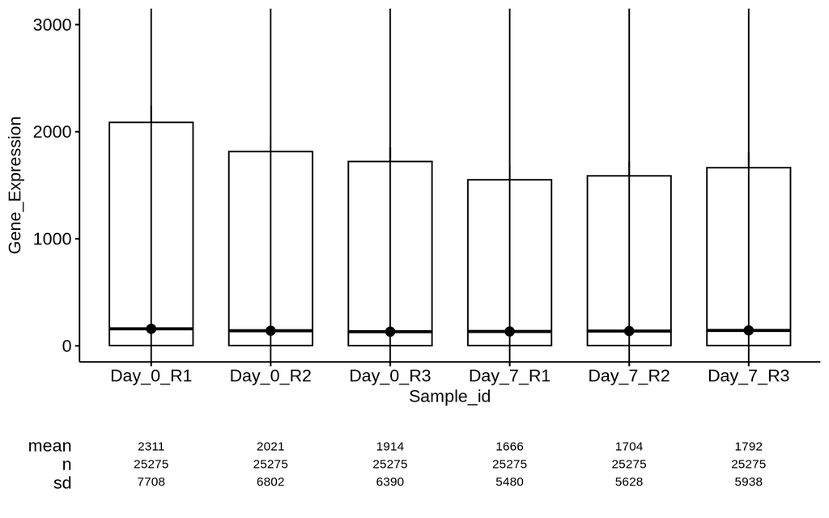

```r
base::library(package="ggpubr", character.only=TRUE)
ggpubr::ggsummarystats(
    data=molten_counts,
    x="Sample_id",
    y="Gene_Expression",
    ggfunc = ggboxplot,
    add = c("median_iqr"),
    summaries=c("mean", "n", "sd"),
    ylim=c(0, 3000)
)
```

Our libraries have very similar means and startad deviation. This is a first hint: very wide range of means would have signed non-normalized data.

## Visualize counts distribution

We can look at the counts distribution and display it with the functions [`ggplot`](https://ggplot2.tidyverse.org/reference/ggplot.html) to build the graph, [`aes`](https://ggplot2.tidyverse.org/reference/aes.html) to deal with aesthetics, and [`geom_density`](https://ggplot2.tidyverse.org/reference/geom_density.html). All these functions come from [`ggplot2`](https://ggplot2.tidyverse.org/index.html).

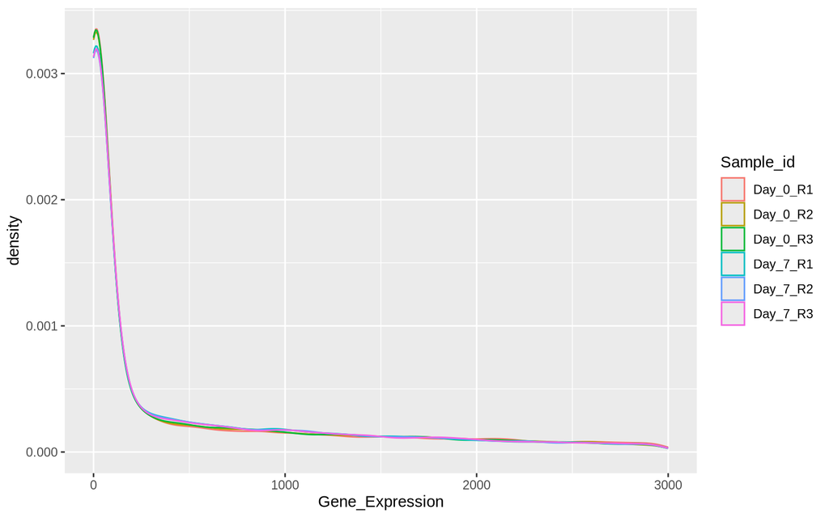

```r
base::library(package="ggplot2", character.only=TRUE)
ggplot2::ggplot(
    data=molten_counts,
    mapping=ggplot2::aes(x=Gene_Expression, color=Sample_id),
) + ggplot2::geom_density() + ggplot2::xlim(0, 3000)
```

Are these distribution “normal” ?

**Hints**

To help you discuss, I have drawn normal distrubitions with means and standard deviations equal to the means and standard deviations of each sample.

I have used the same method as earlier to building the plot. I have used the function [`rnorm`](https://www.rdocumentation.org/packages/stats/versions/3.6.2/topics/Normal) from package [`stats`](https://www.rdocumentation.org/packages/stats/versions/3.6.2) to build the distributions, and the values present in the summary to fill their arguments. These distribution were stored in a data frame, using the function [`data.frame`](https://www.rdocumentation.org/packages/base/versions/3.6.2/topics/data.frame) from [`base`](https://www.rdocumentation.org/packages/base/versions/3.6.2/) package. Since we cannot have negative counts values, I used the function [`pmax`](https://www.rdocumentation.org/packages/base/versions/3.6.2/topics/Extremes) from [`base`](https://www.rdocumentation.org/packages/base/versions/3.6.2/topics/Extremes) package.

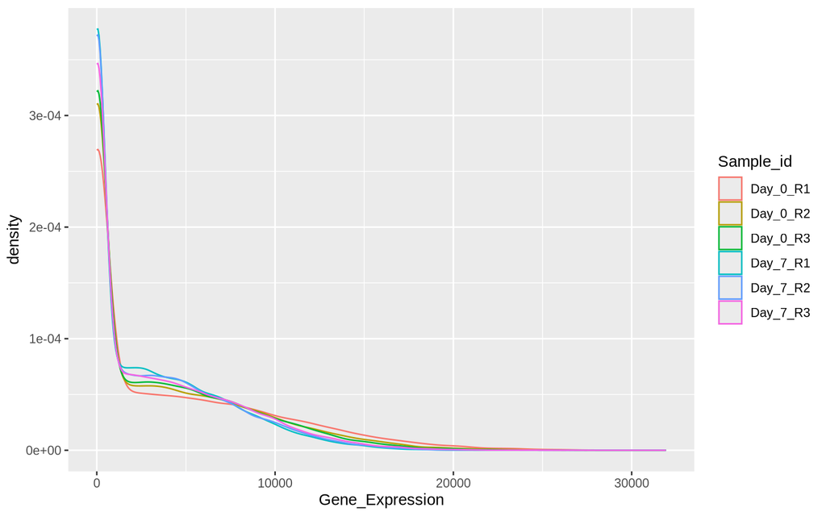

```r
normal_distributions <- reshape2::melt(
    base::data.frame(
        Day_0_R1=base::pmax(stats::rnorm(n=25275, mean=2311, sd=7708), 0),
        Day_0_R2=base::pmax(stats::rnorm(n=25275, mean=2021, sd=6802), 0),
        Day_0_R3=base::pmax(stats::rnorm(n=25275, mean=1914, sd=6390), 0),
        Day_7_R1=base::pmax(stats::rnorm(n=25275, mean=1666, sd=5480), 0),
        Day_7_R2=base::pmax(stats::rnorm(n=25275, mean=1704, sd=5628), 0),
        Day_7_R3=base::pmax(stats::rnorm(n=25275, mean=1792, sd=5938), 0)
    ),
    variable.name="Sample_id",
    value.name="Gene_Expression"
)
ggplot2::ggplot(
    data=normal_distributions,
    mapping=ggplot2::aes(x=Gene_Expression, color=Sample_id),
) + ggplot2::geom_density()
```

With the over-representation of the zeros and very low values, as well as the absence of negative values, we cannot *feel* if the distribution is normal or not.

We can see this is not binomial, but nothing more.

## Run normality test

There is a statistical test that lets us assess the odds of our distribution to be likely normal. That tests is available with the function [`shapiro.test`](https://www.rdocumentation.org/packages/stats/versions/3.6.2/topics/shapiro.test) and is available in the package [`stats`](https://www.rdocumentation.org/packages/stats/versions/3.6.2/). However, the Shapiro test expects *at most* 5 000 observations. This means we would have to take 5 000 random genes and use them in the test. Another solution is to try the Anderson-Darling test, which is know to be a little less significative, but which can handle our complete dataset.

That function expects a vector of numbers, not a data frame. We have to apply that function to all columns of our data frame,] using the function [`apply`](https://www.rdocumentation.org/packages/base/versions/3.6.2/topics/apply) from the package [`base`](https://www.rdocumentation.org/packages/base/versions/3.6.2/).

```r
# Run shapiro on the 5000 first counts
base::apply(counts[1:5000, ], 2, stats::shapiro.test)
```

```
$Day_0_R1

    Shapiro-Wilk normality test

data:  newX[, i]
W = 0.30629, p-value < 2.2e-16


$Day_0_R2

    Shapiro-Wilk normality test

data:  newX[, i]
W = 0.30463, p-value < 2.2e-16


$Day_0_R3

    Shapiro-Wilk normality test

data:  newX[, i]
W = 0.30716, p-value < 2.2e-16


$Day_7_R1

    Shapiro-Wilk normality test

data:  newX[, i]
W = 0.28478, p-value < 2.2e-16


$Day_7_R2

    Shapiro-Wilk normality test

data:  newX[, i]
W = 0.28445, p-value < 2.2e-16


$Day_7_R3

    Shapiro-Wilk normality test

data:  newX[, i]
W = 0.28129, p-value < 2.2e-16
```

```r
# Run the Anderson-Darling test on the complete gene list
base::library(package="nortest", character.only=TRUE)
base::apply(counts, 2, nortest::ad.test)
```

```
$Day_0_R1

    Anderson-Darling normality test

data:  newX[, i]
A = 5191.3, p-value < 2.2e-16


$Day_0_R2

    Anderson-Darling normality test

data:  newX[, i]
A = 5219.5, p-value < 2.2e-16


$Day_0_R3

    Anderson-Darling normality test

data:  newX[, i]
A = 5195.6, p-value < 2.2e-16


$Day_7_R1

    Anderson-Darling normality test

data:  newX[, i]
A = 5097.3, p-value < 2.2e-16


$Day_7_R2

    Anderson-Darling normality test

data:  newX[, i]
A = 5109.7, p-value < 2.2e-16


$Day_7_R3

    Anderson-Darling normality test

data:  newX[, i]
A = 5122.6, p-value < 2.2e-16
```

## Scaling factor

Otherwise, we cannot know the abundance of a gene count.

Imagine a sudent with 5/5 at their exam, and another with 5/20. They do not have the same grade, even if they have the same score.

This is the same with gene expression. Let’s compute the sum of the gene expression using [`colSums`](https://www.rdocumentation.org/packages/base/versions/3.6.2/topics/colSums) from the package [`base`](https://www.rdocumentation.org/packages/base/versions/3.6.2/topics/colSums).

```r
gene_sums <- base::colSums(x=counts, na.rm=TRUE)
```

Then we check the results with the function [`head`](https://www.rdocumentation.org/packages/utils/versions/3.6.2/topics/head) from the [`utils`](https://www.rdocumentation.org/packages/utils/versions/3.6.2/) package.

```r
utils::head(x=gene_sums)
```

Per sample sum of gene expression

|  | x |
| --- | --- |
| Day_0_R1 | 58413055 |
| Day_0_R2 | 51090061 |
| Day_0_R3 | 48372138 |
| Day_7_R1 | 42105904 |
| Day_7_R2 | 43066835 |
| Day_7_R3 | 45283081 |

Maybe yes…? We can’t be sure.

## Conclusion

I can assure you, these data were **not** normalized at all. This was an illustration of why one cannot be sure of the nature of the count table they have in their hands

# Normalize data

## TPM vs RPKM vs RPM vs others

[RNASeq-blog](https://www.rna-seqblog.com/) have a very nice article about normaliztions: [RPKM, FPKM and TPM, clearly explained](https://www.rna-seqblog.com/rpkm-fpkm-and-tpm-clearly-explained/)

The main thing to remember:

1. Never, ever use RPKM. There are no situation where this would be profitable. It has been prooven wrong since 2013, and abandonned since 2015.
2. When considering ChIP-Seq data, with a single-ended library, FPKM and RPKM have the same values.
3. TPM and RPM should always be preferred when you work on exploratory quantification dataset. In other cases (differential expression, etc), other metods can perofrm better.
4. Never compare counts *before* normalization.
5. Never compare counts normalized with different methods.
6. One can always normalize with TPM/RPM and find the original counts back.

## Applying TPM normalization

### Get gene length

To normalize using TPM, we need the gene lengths. The package [`biomaRt`](https://rdrr.io/bioc/biomart/) has the following set of functions used to retrieve this information:

```r
base::library(package="biomaRt", character.only=TRUE)

# Retrieve database information
human <- biomaRt::useMart("ensembl", dataset="hsapiens_gene_ensembl")
gene_lengths <- biomaRt::getBM(
    attributes=c("hgnc_symbol","ensembl_gene_id", "start_position","end_position"),
    filters="hgnc_symbol",
    values=base::rownames(counts),
    mart=human
)

# Compute gene lengths
gene_lengths$size <- gene_lengths$end_position - gene_lengths$start_position
```

Then we check the results with the function [`head`](https://www.rdocumentation.org/packages/utils/versions/3.6.2/topics/head) from the [`utils`](https://www.rdocumentation.org/packages/utils/versions/3.6.2/) package.

```r
utils::head(x=gene_lengths)
```

| hgnc_symbol | ensembl_gene_id | start_position | end_position | size |
| --- | --- | --- | --- | --- |
| A1BG | ENSG00000121410 | 58345178 | 58353492 | 8314 |
| A1CF | ENSG00000148584 | 50799409 | 50885675 | 86266 |
| A2M | ENSG00000175899 | 9067664 | 9116229 | 48565 |
| A2ML1 | ENSG00000166535 | 8822621 | 8887001 | 64380 |
| A2MP1 | ENSG00000256069 | 9229376 | 9275817 | 46441 |
| A3GALT2 | ENSG00000184389 | 33306766 | 33321098 | 14332 |

### Compute RPK

We can now compute RPK, using the function [`sweep`](https://rdocumentation.org/packages/base/versions/3.6.2/topics/sweep) from the package [`base`](https://rdocumentation.org/packages/base/versions/3.6.2/).

```r
rpk <- base::sweep(
    x=sorted_counts,
    MARGIN=2,
    STATS=gene_lengths$size,
    FUN="/"
)
```

Then we check the results with the function [`head`](https://www.rdocumentation.org/packages/utils/versions/3.6.2/topics/head) from the [`utils`](https://www.rdocumentation.org/packages/utils/versions/3.6.2/) package.

```r
utils::head(x=rpk)
```

Read per kilobase

|  | Day_0_R1 | Day_0_R2 | Day_0_R3 | Day_7_R1 | Day_7_R2 | Day_7_R3 |
| --- | --- | --- | --- | --- | --- | --- |
| FASN | 16.534280 | 1.3965293 | 2.356059 | 0.4537745 | 0.6503951 | 2.2406503 |
| SCD | 4.230524 | 12.0384926 | 5.808364 | 1.0860524 | 0.2421982 | 0.6795804 |
| ENO1 | 3.906989 | 12.9171696 | 6.890665 | 3.5886300 | 7.9833202 | 4.6112392 |
| KRT8 | 8.223704 | 3.2722941 | 1.715082 | 0.1448473 | 0.3298193 | 5.5309969 |
| FN1 | 1.361744 | 0.5799293 | 3.137102 | 5.9495758 | 6.5536072 | 1.9921985 |
| S100A6 | 4.931330 | 1.2568454 | 13.443090 | 0.2973814 | 0.3137402 | 0.6238203 |

### Compute per milion scaling factor

We already computed library size earlier, and sotred it into a variable named `gene_sums`. The same method is used to sum up all the reads per kilobase.

The scaling factor is obtained by dividing that number by 1 milion.

```r
scaling_factor <- base::colSums(rpk) / 1000000
base::print(scaling_factor)
```

```
  Day_0_R1   Day_0_R2   Day_0_R3   Day_7_R1   Day_7_R2   Day_7_R3
0.04784332 0.04122275 0.03911437 0.03606431 0.03665194 0.03870672
```

### Get TPM

Finally, we divide the RPK by the scaling factor:

```r
tpm <- rpk / scaling_factor
base::colSums(tpm)
```

```
 Day_0_R1  Day_0_R2  Day_0_R3  Day_7_R1  Day_7_R2  Day_7_R3
1209606.7 1039541.3  989045.4  908589.3  927501.2  974809.3
```

Then we check the results with the function [`head`](https://www.rdocumentation.org/packages/utils/versions/3.6.2/topics/head) from the [`utils`](https://www.rdocumentation.org/packages/utils/versions/3.6.2/) package.

```r
utils::head(x=tpm)
```

|  | Day_0_R1 | Day_0_R2 | Day_0_R3 | Day_7_R1 | Day_7_R2 | Day_7_R3 |
| --- | --- | --- | --- | --- | --- | --- |
| FASN | 345.59221 | 38.72331 | 49.24530 | 12.582370 | 13.594272 | 62.12930 |
| SCD | 102.62596 | 328.45441 | 140.90191 | 29.631509 | 5.875354 | 18.54145 |
| ENO1 | 99.88627 | 333.71904 | 176.16711 | 92.713357 | 204.101975 | 119.13278 |
| KRT8 | 228.02889 | 68.39605 | 47.55622 | 3.027534 | 9.145310 | 115.60645 |
| FN1 | 37.15339 | 14.06819 | 85.59169 | 144.327489 | 178.806540 | 48.32765 |
| S100A6 | 127.40243 | 32.13257 | 347.30636 | 7.602868 | 8.105574 | 15.94862 |

## Conclusions

More about normalizations [on the web](https://www.reneshbedre.com/blog/expression_units.html).

# Filtering

Removing rows filled with zeros is a common practice. While this does not bother differential analysis, or quality controls, these rows full of zeros take require memory to be stored, and take time to compute.

Let’s remove them. We can use the function [`dim`](https://www.rdocumentation.org/packages/base/versions/3.6.2/topics/dim) from package [`base`](https://www.rdocumentation.org/packages/base/versions/3.6.2) to check how many rows vere filtered out.

```r
base::dim(x=tpm)
```

```
[1] 25275     6
```

```r
tpm <- tpm[base::rowSums(tpm[]) > 0, ]
base::dim(x=tpm)
```

```
[1] 22318     6
```

Then we check the results with the function [`head`](https://www.rdocumentation.org/packages/utils/versions/3.6.2/topics/head) from the [`utils`](https://www.rdocumentation.org/packages/utils/versions/3.6.2/) package.

```r
utils::head(x=tpm)
```

|  | Day_0_R1 | Day_0_R2 | Day_0_R3 | Day_7_R1 | Day_7_R2 | Day_7_R3 |
| --- | --- | --- | --- | --- | --- | --- |
| FASN | 345.59221 | 38.72331 | 49.24530 | 12.582370 | 13.594272 | 62.12930 |
| SCD | 102.62596 | 328.45441 | 140.90191 | 29.631509 | 5.875354 | 18.54145 |
| ENO1 | 99.88627 | 333.71904 | 176.16711 | 92.713357 | 204.101975 | 119.13278 |
| KRT8 | 228.02889 | 68.39605 | 47.55622 | 3.027534 | 9.145310 | 115.60645 |
| FN1 | 37.15339 | 14.06819 | 85.59169 | 144.327489 | 178.806540 | 48.32765 |
| S100A6 | 127.40243 | 32.13257 | 347.30636 | 7.602868 | 8.105574 | 15.94862 |

# Graphs

```r
#corr_matrix <- cor(data_normalized)
```

# Save filtered table